# Data Sciences Capstone Project Milestone Report

R Mofidi

25/08/2020

## Milestone Report

### Background

In the last decade people have started spending ever increasing amount of time on their mobile devices, performing a range of activities including accessing social networking sites, email, reading published contents such as books and newspapers. Typing on the go and on mobile devices can be a serious challenge. Predictive texting is crucial for easing such tasks. SwiftKey, builds a smart keyboard that makes it easier for people to type on their mobile devices, through the use of predictive texting.

This capstone project involves analyzing and cleaning a large body ‘corpus’ of text documents to discover the structure in the data and how words are put together. This will form a resource from which build a predictive text product.

The milestone report covers the first part of this activity which includes the following steps

1- R packages used in the project

2- The data source and downloading

3- Preliminary data analysis

4- Preprocessing steps

5- Creating NGrams and visualising the data

## R packages used in the project

The following R packages were used in this project. They include the “tm” package, the “NLP” package and the “quanteda” packages.

[output not shown]

[output not shown]

[output not shown]

## Downloading the data

The dataset used for this project involves a alarge body of text in 4 languages including English, Finnish, German and russian. The folder containing US English text is used for further analysis "en_US. This report is an exploratory analysis of the data supplied for training the model used for the capstone project.

```r
if(!file.exists("~/data")){dir.create("~/data")}
fileUrl <- "https://d396qusza40orc.cloudfront.net/dsscapstone/dataset/Coursera-SwiftKey.zip"
download.file(fileUrl,destfile="~/data/capstone.zip")
if(!file.exists("~/data/capstone.zip")){
  unzip("~/data/capstone.zip", exdir="~/data")
}
```

## Read the files datset

This folder includes 3 large txt files including blogs, news and twitter messages. The blogs represent colloquial English, the news represents formal English and Twitter messages represent abbreviated informal English. The following table lists the file sizes in bytes, the number of words and number of words per line for each class of text file.

```r
##read US English the text files
blogs <- readLines("~/data/final/en_US/en_US.blogs.txt", encoding="UTF-8", warn=FALSE, skipNul=TRUE)
news <- readLines("~/data/final/en_US/en_US.news.txt", encoding="UTF-8", warn=FALSE, skipNul=TRUE)
twitter <- readLines("~/data/final/en_US/en_US.twitter.txt", encoding="UTF-8", warn=FALSE, skipNul=TRUE)

##blogs
blog_line<- length(blogs); blogs_size<- object.size(blogs);
Blog_words<- sum(sapply(strsplit(blogs,"\\s+"),length))
Bl_words_per_line<- round(Blog_words/blog_line,2)

##news
news_line<- length(news); news_size<- object.size(news);
News_words<- sum(sapply(strsplit(news,"\\s+"),length))
NWS_words_per_line<- round(News_words/news_line,2)

##twitter
twitter_line<- length(twitter); twitter_size<- object.size(twitter);
twitter_words<- sum(sapply(strsplit(twitter,"\\s+"),length))
twt_words_per_line<- round(twitter_words/twitter_line,2)

Lines<- rbind(blog_line, news_line, twitter_line)
Size<- rbind(blogs_size,news_size, twitter_size)
Words<- rbind(Blog_words, News_words, twitter_words)
Word_per_line<- rbind(Bl_words_per_line, NWS_words_per_line, twt_words_per_line)

table1<- cbind(Lines, Size, Words, Word_per_line)
row.names(table1)<- c("Blogs", "News", "Twitter")
colnames(table1)<- c('number of lines', 'Size', 'total number of words', 'Words per line')
table1
```

```
##         number of lines      Size total number of words Words per line
## Blogs            899288 267758632              37334131          41.52
## News              77259  20729472               2643969          34.22
## Twitter         2360148 334484992              30373583          12.87
```

## Create a corpus of text for analysis

A corpus is language resource which cinsists of a large body of structured text which can be analysed in order to validate linguistic rules or for NLP.

```r
SampleB<- sample(blogs, round(length(blogs)*0.025))
SampleN <- sample(news, round(length(news)*0.025))
SampleT <- sample(twitter, round(length(twitter)*0.025))
text_sample <- paste(SampleB,SampleN,SampleT)

documents<- Corpus(VectorSource(text_sample))

documents <- tm_map(documents, content_transformer(tolower))
documents <- tm_map(documents, stripWhitespace)
documents <- tm_map(documents, removePunctuation)
documents <- tm_map(documents, removeNumbers)
```

## Simple data visualisation

N-grams are a contiguus sequence of N items from a given sample of text or speech. N grams can be phenomes, syllables, letters or words. They can be unitgrams bigrams or trigrams, where the prefix N also denotes their size in the number of words. *N-grams* are essentially a probobalistic language model and are used to predict the next item in a sequene of model. N-grams are basically a n-1 Markov model. In the following example I used Ngram Tokenizer function which breaksdown the text into words when it encounters a list of specified characters and then plotted unigrams, bigrams and trigrams by the frequency they appear in the sample curpus. The following word clouds illustrate the frquently used words in the sample corpus of test as well as individual word clouds pertaining to the sample texts from blogs, news and tweets.

### Sample text Corpus word cloud

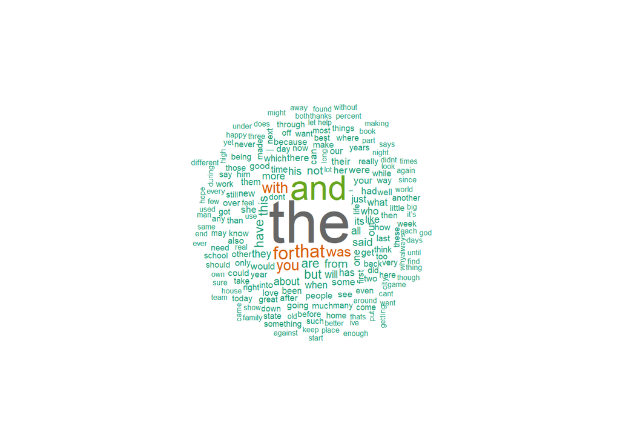

```r
wordcloud(documents, max.words=200, random.order=FALSE,colors= brewer.pal(8, "Dark2"))
```

### Sample Blog Corpus word cloud

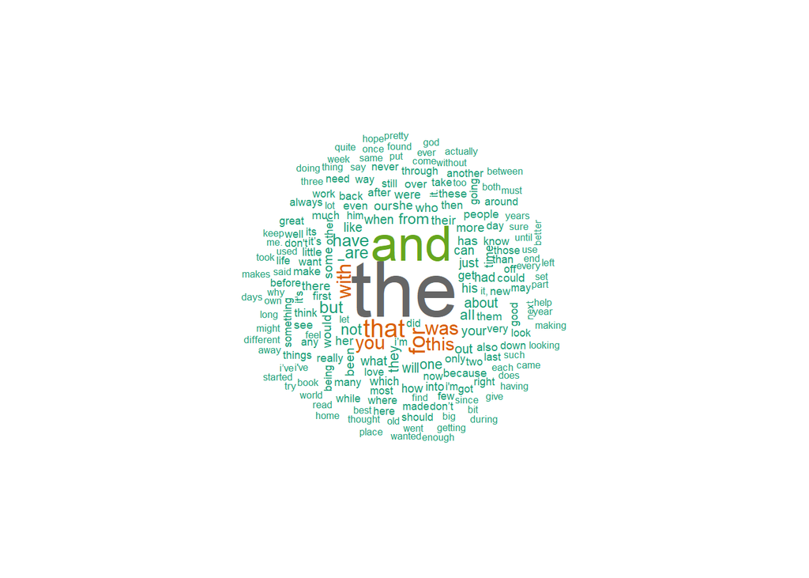

```r
BLOG<- Corpus(VectorSource(SampleB))
wordcloud(BLOG, max.words=200, random.order=FALSE,colors= brewer.pal(8, "Dark2"))
```

### Sample News Corpus word cloud

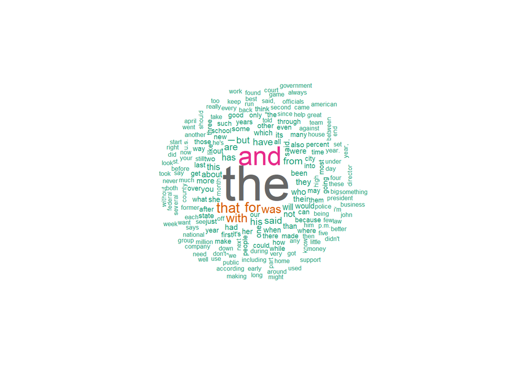

```r
NEWS<- Corpus(VectorSource(SampleN))
wordcloud(NEWS, max.words=200, random.order=FALSE,colors= brewer.pal(8, "Dark2"))
```

### Sample Tweets Word cloud

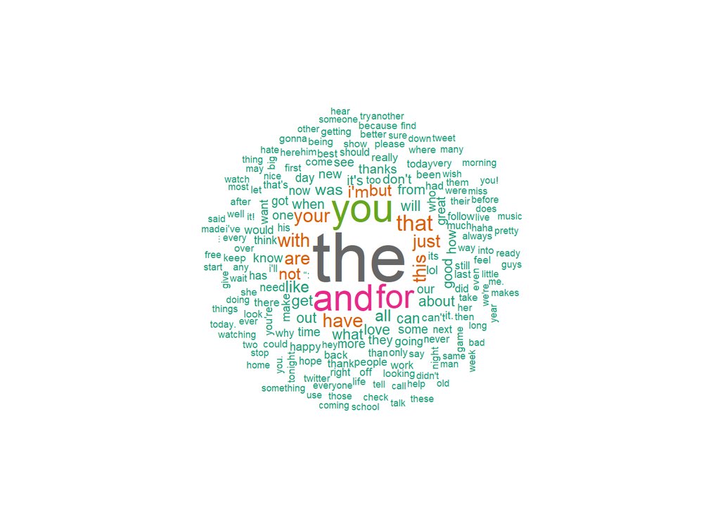

```r
TWEET<- Corpus(VectorSource(SampleT))
wordcloud(TWEET, max.words=200, random.order=FALSE,colors= brewer.pal(8, "Dark2"))
```

## Unigrams

```r
unigram <- function(x) ngram_asweka(x, min = 1, max = 2, sep = " ")
tdm<-TermDocumentMatrix(documents,control=list(wordLengths=c(1,Inf), tokenize=unigram))
unigramCorpus<- findFreqTerms(tdm, lowfreq=1000)
unigramCorpusN<- rowSums(as.matrix(tdm[unigramCorpus,]))
unigramCorpusT<- data.frame(Word=names(unigramCorpusN), frequency=unigramCorpusN)
UnigramSort<- unigramCorpusT[order(-unigramCorpusT$frequency),]
```

### word frequency excluding the stopwords

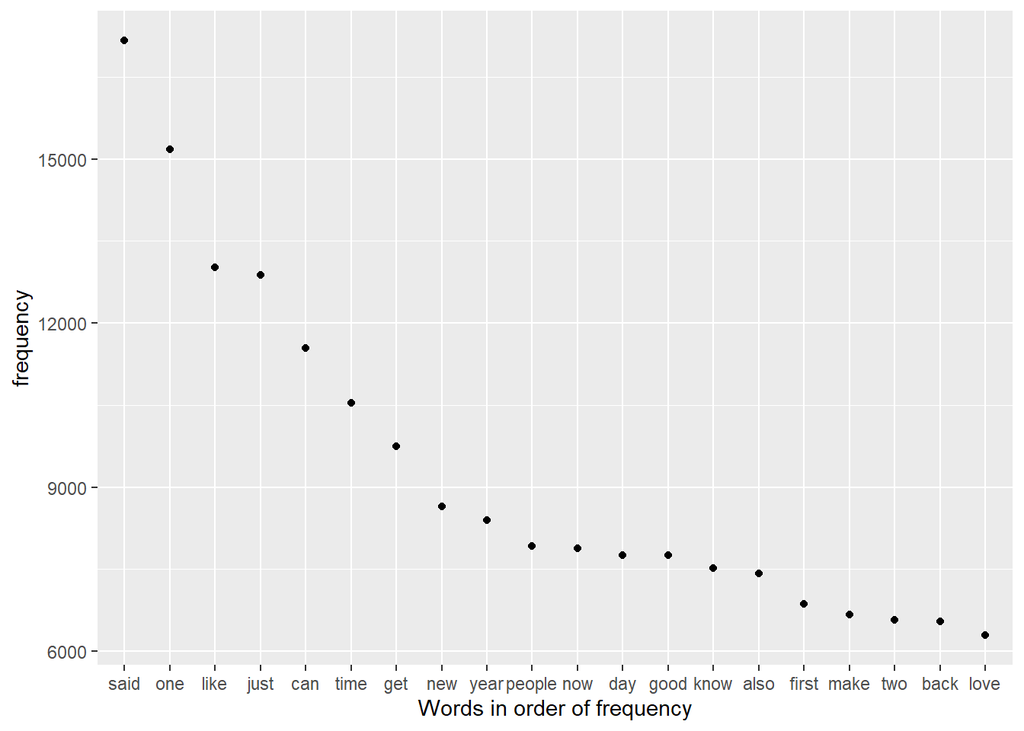

```r
unigram<- tokenize_ngrams(text_sample, n=1, n_min =1, stopwords=stopwords::stopwords("en"))
unigram.df<- data.frame(V1= as.vector(names(table(unlist(unigram)))), V2= as.numeric(table(unlist(unigram))))
names(unigram.df)<-c("word", "frequency")
unigramSort<- unigram.df[with(unigram.df, order(-unigram.df$frequency)),]
ggplot(unigramSort[1:20,])+ geom_point(aes(x=reorder(word, -frequency), y=frequency))+ labs(x="Words in order of frequency")
```

### Bigrams

Bigrams are 2 word n-grams. The following plot illustrates the frequency of top 20 most frequent ngrams used in the sample corpus of data.

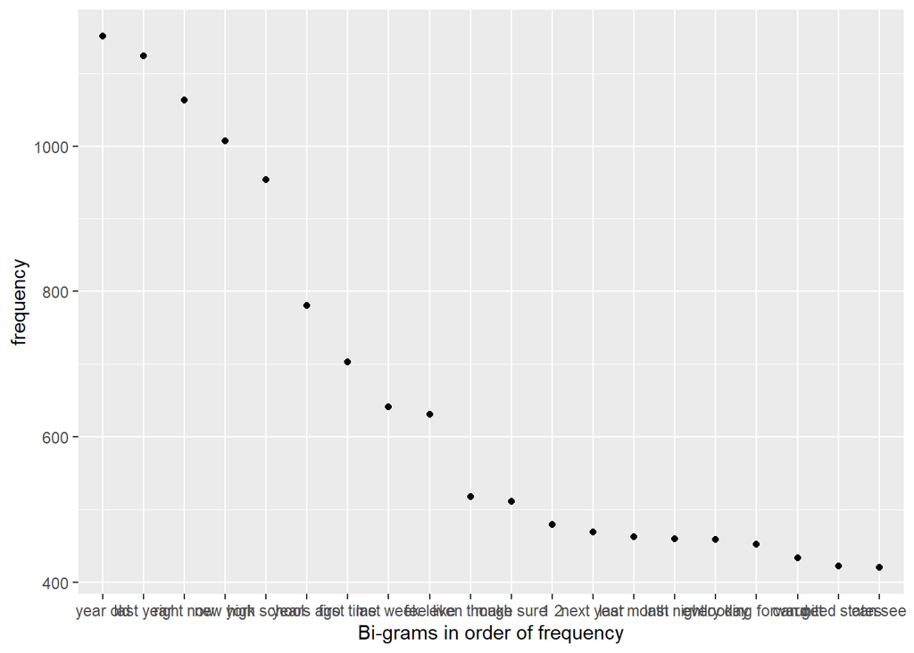

```r
bigram<-  tokenize_ngrams(text_sample, n=2, n_min =2, stopwords=stopwords::stopwords("en"))
bigram.df<- data.frame(V1= as.vector(names(table(unlist(bigram)))), V2= as.numeric(table(unlist(bigram))))
names(bigram.df)<-c("word", "frequency")
bigramSort<- bigram.df[with(bigram.df, order(-bigram.df$frequency)),]
ggplot(bigramSort[1:20,])+ geom_point(aes(x=reorder(word, -frequency), y=frequency))+ labs(x="Bi-grams in order of frequency")
```

### Trigrams

The last analysis perofrmed in this report is analysis of frequency of the trigrams or three consecutive word segments of the sample corpus of text.

[figure not shown]

```r
trigram<-  tokenize_ngrams(text_sample, n=3, n_min =3, stopwords=stopwords::stopwords("en"))
trigram.df<- data.frame(V1= as.vector(names(table(unlist(trigram)))), V2= as.numeric(table(unlist(trigram))))
names(trigram.df)<-c("word", "frequency")
trigramSort<- trigram.df[with(trigram.df, order(-trigram.df$frequency)),]
ggplot(trigramSort[1:20,])+ geom_point(aes(x=reorder(word, -frequency), y=frequency))+ labs(x="Tri-grams in order of frequency")
```

## Conclusions

The above data analysis through the use of ngrams has been very helpful in forming a training dataset for predicting the next word occuring. Following this preliminary data analysis I aim to improvethe quality of n-grams and use them to develope a markov-chain model to predict the frequency of unobserved n-grams. This can then be used to develop a word prediction model. This model will then be implemented into a shinyapp to form a user friendly interface for the app.